# 参考区间

hiox-tech

2026-08-06

# 1 分析目的

参考区间（reference interval，RI）由参考样本群体的测量结果界定，用于解释个体结果的正常范围， 对应 CLSI EP28-A3c。`ivdtools` 提供三种方法：百分位数法（nonparametric）、参数法（parametric， 正态或对数正态）、稳健法（robust）。三种方法对样本量、分布形态和离群值的敏感性不同，建议同时对 同一数据应用多种方法进行比较，并在建立参考区间前先做异常值检测与正态性评估。

本文演示用 `outliers_test()` 与 `normal_test()` 做预先分析，再调用 `reference_interval(method = "all")` 同时输出三种方法的参考区间。示例数据为确定性的教学数据（n=120，轻度右偏并含离群值）。

```r
library(ivdtools)
library(readr)
```

# 2 函数概述

| 函数 | 主要用途 | 关键输入或输出 |
| --- | --- | --- |
| `outliers_test()` | 异常值检测 | Grubbs / ESD / Dixon / IQR |
| `normal_test()` | 正态性检验与图形 | `method="auto"` 按样本量选检验 |
| `reference_interval()` | 三种方法参考区间 | `method="all"`、`interval`、`ci`、`id` |
| `plot.reference_interval()` | 分方法绘制区间 | jitter + 上下限 |

# 3 示例：三法并用的参考区间

## 3.1 读取和核验数据

```r
ri_data <- read_csv("./data/reference-interval.csv", show_col_types = FALSE)
ri_data <- as.data.frame(ri_data)
str(ri_data)
```

```
#> 'data.frame':    120 obs. of  2 variables:
#>  $ id   : chr  "S001" "S002" "S003" "S004" ...
#>  $ value: num  131.1 100.8 106 74.3 116.9 ...
```

## 3.2 预先分析一：异常值检测

EP28 建议在建立参考区间前审查离群值。样本量 n=120，不适合 Dixon（Dixon 仅适用于 n≤30）， 使用 Grubbs 与广义 ESD：

```r
outliers_test(ri_data, col = "value", method = "grubbs")
```

```
#> Grubbs Outliers Test
#>   Data:   ri_data
#>   Column: value (n = 120, missing = 0)
#>   Parameters: alpha = 0.05
#>   Outliers: 1
#>
#>   Index            Value      G stat    Critical
#>   -------------------------------------------
#>   88            183.0000      4.0104      3.4451
```

```r
outliers_test(ri_data, col = "value", method = "esd", r = 3)
```

```
#> Generalized ESD Outliers Test
#>   Data:   ri_data
#>   Column: value (n = 120, missing = 0)
#>   Parameters: alpha = 0.05, r = 3
#>   Outliers: 2
#>
#>   Index            Value      R stat    Critical
#>   -------------------------------------------
#>   88            183.0000      4.0104      3.4451
#>   57            178.0000      4.0576      3.4424
```

> **参数说明：** `outliers_test()` 的 `method` 可选 `"grubbs"`、`"esd"`、`"dixon"`、`"iqr"`； ESD 通过 `r` 指定最多检出数，Dixon 通过 `type` 指定尾部（`"both"`/`"min"`/`"max"`），IQR 通过 `coef` 指定倍数（默认 1.5）。**检测到离群值不代表应删除**——应回查原始记录、实验过程与方案规定， 在有充分理由时进行包含/不包含的敏感性分析。

## 3.3 预先分析二：正态性检验

```r
nt <- normal_test(ri_data, col = "value", method = "auto")
nt
```

```
#>
#> Normality Test
#>   Data:   ri_data
#>   Column: value (n = 120, missing = 0)
#>   Method:     Anderson-Darling
#>
#>   A = 1.7577, p = 0.0002
```

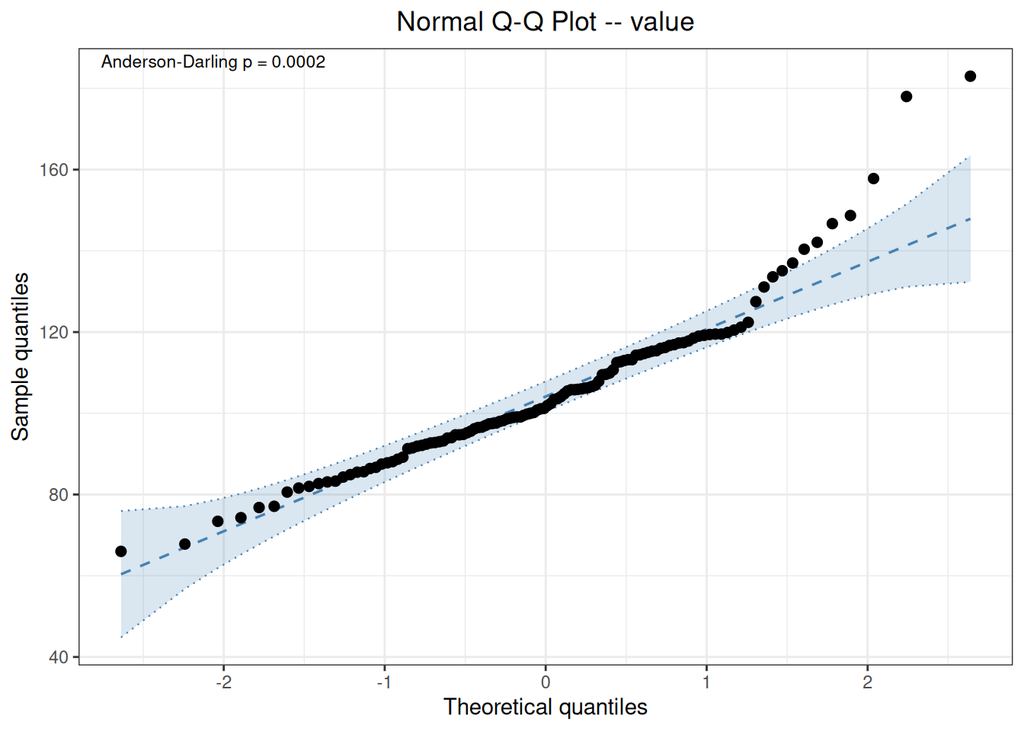

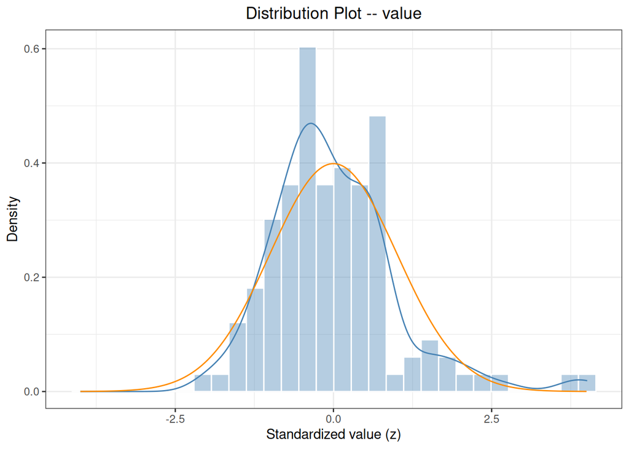

```r
plot(nt, type = c("qq", "his"))
```

`method="auto"` 对 n=120 自动选择 Anderson-Darling 检验，p 值很小，提示数据不服从正态分布 （该数据右偏并含离群值）。QQ 图与直方图可直观确认偏态。

## 3.4 三法并用的参考区间

```r
ri <- reference_interval(
  ri_data,
  col = "value",
  interval = 0.95,
  ci = 0.95,
  method = "all",
  id = "id"
)
print(ri)
```

```
#>
#> Reference Interval Analysis
#>   Column:              value
#>   Reference interval:  95% (alpha = 0.025)
#>   Confidence level:    0.95
#>   ID variable:         id
#>   Complete cases:      120 / 120
#>
#>   No missing values.
#>   No duplicate IDs found.
#>
#>   Percentile (quantile type 6, CLSI EP28-A3c)
#>     Lower = 73.4225  [66.0000, 80.6000]
#>     Upper = 157.5725  [137.0000, 183.0000]
#>
#>   Parametric (log-transformed, Shapiro-Wilk p = 0.0661)
#>     Lower = 73.2539  [69.3807, 77.3434]
#>     Upper = 145.9407  [138.2241, 154.0880]
#>
#>   Robust (Huber M-estimation (k=1.5, 16 iter) + MAD)
#>     Lower = 72.1573  [66.6693, 77.3435]
#>     Upper = 134.7365  [127.7757, 142.2815]
```

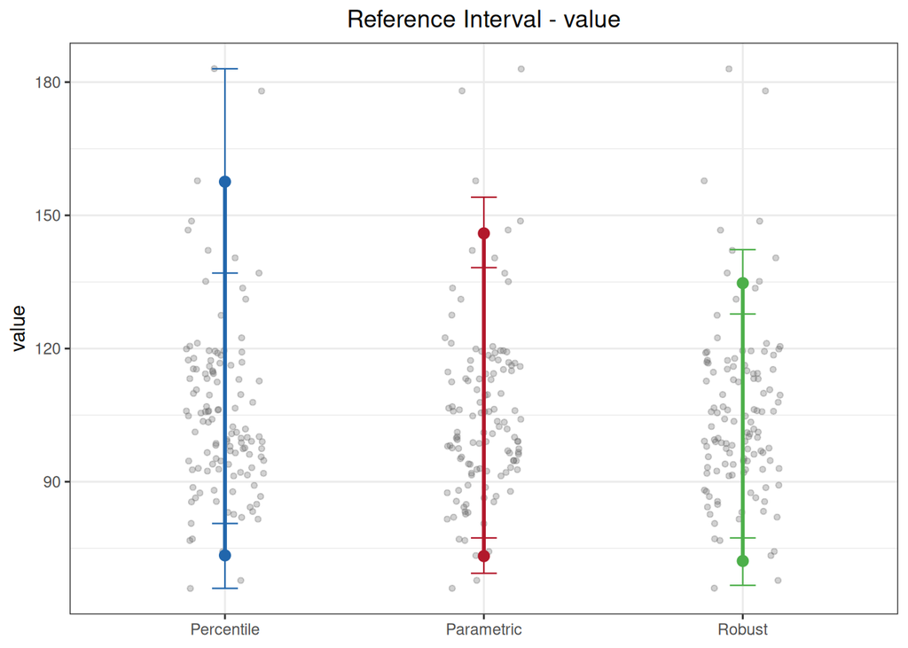

```r
plot(ri)
```

> **参数说明：** `reference_interval()` 中 `interval` 是参考区间覆盖度（默认 0.95，对应 2.5%–97.5%）， `ci` 是区间端点的置信水平，两者含义不同。`method` 可取 `"percentile"`、`"parametric"`、`"robust"`、 `"all"` 或其中任意组合。`id` 用于重复样本检测。

本示例三种方法结果比较：

- **百分位数法**（73.4–157.6）：非参数、不作分布假设，但上限被两个大离群值抬高；
- **参数法**（73.3–145.9）：自动检测到数据非正态后做了 log 变换（`transformed=TRUE`）再回代；
- **稳健法**（72.2–134.7）：基于 Huber M 估计与 MAD，对离群值最稳健。

百分位法上限明显高于稳健法，正是离群值影响的表现。**参考区间应在样本来源、样本量、分布特征与研究 方案指导下选择报告方法**，不宜只挑结果”好看”的一种。

# 4 结果判读要点

1. **方案先定**：明确参考人群、纳入排除标准、样本量（百分位法 EP28 建议 ≥120）与分区策略。
2. **先检后算**：先做异常值检测与正态性评估，记录离群值处理决定（是否排除、依据）。
3. **方法可比**：三法同出便于发现离群值或分布假设对区间的影响，报告时说明所选方法与理由。
4. **参数区分**：区分 `interval`（覆盖度）与 `ci`（端点置信度），不要混用。
5. **转换透明**：参数法自动 log 变换时要报告变换类型与回代方式。
6. **非唯一结论**：参考区间不等同于临床决定限，也不自动构成可接受性判定。